# Group A - Data Analysis

OWEN O’CONNOR | DAVID SKERRITT | WARREN LANGRIDGE | OISIN HEANEY

2025

```r
library(tidyverse)
library(plotly)
library(ggiraph)
library(paletteer)
```

# Introduction

This project explores the gender pay divide among Level 8 graduates in the fields of Natural Sciences, Mathematics, and Statistics in Ireland. Focusing specifically on the salary growth over the course of a career, we analyze how pay disparities manifest at three key stages: the beginning of graduates’ careers, across-career progression, closing with a spotlight on the final years captured within the data. using this CSO data, we examine trends and gaps in salary between male and female graduates. Our analysis uses data visualization techniques learned during ST302 to provide a clearer understanding of one of the stories hidden within the given dataset.

# Data adjustments

Initially we are given data with data with 12,000 rows(/observations) and 7 columns(/variables).  
These rows are as follows:

- Column 1 - “statistic”
- Column 2 - year
- Column 3 - gender
- Column 4 - field of study
- Column 5 - NFQ Level
- Column 6 - years since graduation
- Column 7 - “measure of statistic”

Since we know all of our data relates to “Salary in Natural Sciences, Mathematics and Statistics for level 8 graduates”, we can remove the columns relating to NFQ Level and field of study. These just hold the same information and so are redundant. They only making our dataset larger, so that it’s takes more memory and is more computationally expensive to work with. Hence after loading in the dataset we remove these columns.

Finally, there is a huge amount of NA’s built into this dataset. The structure leaves spaces for salaries of individuals 5, 6, 7, and so on ‘years from graduation’, when that data did not exsist at the time of the collection. As a result of this na.omit will give us a much clearer idea of the ‘true’ dimensions of our data.

We thought it might also be handy to present the data in a wider format, this is much easier to read - instead of “statistic” and “measure of statistic”, we are presented with very clear 25th/50th and 75th percentile earnings for each combination of year/years since graduation and gender combination. +Plus consistent shorter column names makes for easier usage.

There is also adjustments that may need to be made for individual plots but we felt that these adjustments would make the data more suitable for all group members to work with.

```r
load("gradMS.Rdata")

gradMS <- gradMS[,-c(4,5)] # Removes 2 columns / 24,000 cells

gradMS <- gradMS %>%
  filter(Gender != "Other gender") # this removes 300 rows / 1,500 cells

gradMS <- gradMS %>%
  na.omit() # this removes 405 rows / 2,025 cells

gradMS_wider <- gradMS |> # we use a base pipe here because magrittr pipes play weird with '.'
  pivot_wider(names_from = Statistic, values_from = .) |> # resulting table is 165 rows x 6 columns
  rename(
    year = Graduation.Year,
    gender = Gender,
    yearsGrad = Years.Since.Graduation,
    p25 = `P25 Earnings of Graduates`,
    p50 = `P50 Earnings of Graduates`,
    p75 = `P75 Earnings of Graduates`
  ) |> # consistent informative names.
  mutate(year = as.factor(year),
         yearsGrad = as.factor(yearsGrad)) # more appropriate encoding
```

# Analysis

Each contributor has given their interpretation follow their graph. Here we’d like to take the opportunity to acknowledge visualisation decision we’ve made and applied to all of our plots. Also - we have used colours from the ‘paired’ pallete from color brewer, these colors are distinguishable if the images are desaturated and colourblind safe for Deuteranope, Protanope and Tritanope colourblindness.  
This was verified @ http://hclwizard.org  
pink and blue adjacent colors are used to differentiate between male and female as they’re intuitive, it’s easier for a user to recognize as opposed to rationalize.  
We’ve also applied a minimal theme across all plots as if reduces visual noise - reducing the cognitive load on viewers and focusing on attention on what matters.

## Question 1 - Owen

### Analysis of gender pay gap of newly-graduated maths/stats students across different percentiles.

```r
gradMS_Q1 <- gradMS_wider %>%
  filter(gender != "All genders") %>% # We're only interested in the difference
  filter(yearsGrad == 1) %>% # We're only interested in newly grads
  select(!yearsGrad) %>% # taking 'all but the yearsGrad' column
  pivot_wider(names_from = gender, values_from = c(p25, p50, p75)) %>%
  mutate(
    payDifLower = (p25_Male / p25_Female) - 1,
    payDifMedian = (p50_Male / p50_Female) - 1,
    payDifUpper = (p75_Male / p75_Female) - 1
  ) # Use of a ratio allows for comparison independent of scale.

gradMS_Q1_final <- gradMS_Q1 %>%
  pivot_longer(
    cols = c(payDifLower, payDifMedian, payDifUpper),
    names_to = "quartile",
    values_to = "payRatio"
  ) %>% # Gives us a row for each year's lower/middle/upper quartiles
  mutate(quartile = factor(quartile,
                             levels = c("payDifUpper", "payDifMedian", "payDifLower"),
                             labels = c("upper quartile", "median", "lower quartile"))) %>%
  select(year, quartile, payRatio) # Only saving the information necessary for the plot

gradMS_Q1_final <- gradMS_Q1_final %>%
  mutate(tooltip_text = paste("Ratio:", round(payRatio, 2))) # Added for interactivity
```

```r
p1 <- gradMS_Q1_final %>%
  ggplot(aes(x = year, y = payRatio, fill = payRatio < 0)) +
  geom_bar_interactive(
    stat = "identity",
    aes(tooltip = tooltip_text)
  ) +
  facet_grid(quartile ~ .,
             labeller = labeller(quartile = c(
               "payDifLower" = "Lower",
               "payDifMedian" = "Median",
               "payDifUpper" = "Upper"
               )),
             switch = "y") +
  scale_fill_manual(values = c("#1F78B4FF", "#FB9A99FF"),  # Male, Female
                    name = "Bias",
                    labels = c("Male", "Female")) +
  labs(title = "New grad pay diff @ 25th/50th/75th percentile earnings",
       subtitle = "For new maths/stats graduates",
       y = "",
       x = "Graduation Year") +
  theme_minimal() +
  theme(axis.text.y = element_blank(),
        strip.text.y.left = element_text(angle = 0, hjust = 1))
# removes measures on y-axis, reducing visual noise

girafe(ggobj = p1) |>
  girafe_options(opts_sizing(rescale = TRUE, width = .75))
```

[interactive chart not shown]

This plot illustrates the gender pay gap for recent mathematics and statistics graduates at the 25th, 50th, and 75th earnings percentiles, measured one year after graduation.

Overall, a consistent bias toward male graduates is evident across most years and percentiles, particularly at the 75th percentile, where men consistently earn more than women in the early and later years. The median (50th percentile) also reflects a male pay advantage in most cohorts.

A notable exception occurs around 2015, where the trend temporarily reverses:

- At the 25th percentile, there is a pronounced female advantage, with women earning more than men in two consecutive years.
- This reversal is present to a lesser extent at the median, and absent at the 75th percentile, suggesting the pay gap reversal was concentrated among lower-earning graduates.

By 2018, the male advantage reasserts itself across all percentiles, particularly at the lower end of the payscale.

From this graphic we may gather that there have been short-term changes in salary practices.  
The persistent bias at the top end informs us to the structural dynamics disproportionately benefiting men in higher-paying positions.

## Question 2 - David

### Graduate Earnings Over Time

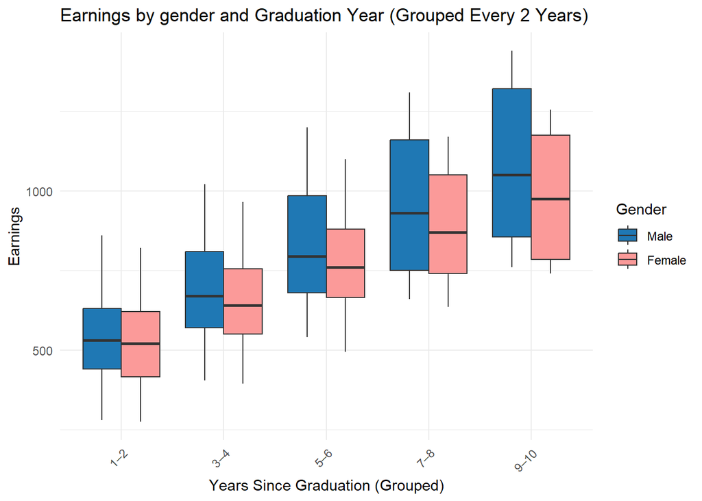

```r
gradMS %>%
  filter(Gender %in% c("Male", "Female")) %>%   # Keep only Male and Female
  ggplot(aes(x = cut(Years.Since.Graduation,
                     breaks = seq(0, 10, by = 2),
                     labels = c("1–2", "3–4", "5–6", "7–8", "9–10"),
                     include.lowest = TRUE),
             y = .,
             fill = Gender)) +
  geom_boxplot(position = position_dodge(width = 0.75)) +
  scale_fill_manual(values = c("Male" = "#1F78B4FF", "Female" = "#FB9A99FF"))+
  theme_minimal() +
  labs(title = "Earnings by gender and Graduation Year (Grouped Every 2 Years)",
       x = "Years Since Graduation (Grouped)",
       y = "Earnings") +
  theme(axis.text.x = element_text(angle = 45, hjust = 1))
```

This plot tracks and displays the difference in earnings for graduates of the mathematical and statistical sciences over a 10 year period. The Years Since Graduation variable from the data set has been modified by grouping every two years together, which is displayed across the x-axis of the plot. The variable Earnings is displayed along the y-axis. The code has been filtered to include only the Male and Female variables in the gender variable.

Upon initially viewing the plot, it is clear to see an upward trend in earnings over time across both Male and Female genders. As displayed on each box plot, the medians show an increase across each grouped year. For example, the minimum earnings for Females after 1-2 years is 275.00, while after years 9-10 the minimum is 740.00. A significant increase. The interquartile range (spread of earnings) is smaller for newer graduates, however there is a notable increase in the IQR for the later years. Potential reasons for this increase include better access to more senior high paying roles that require more experience.

The next most obvious observation from the plot is the difference in earnings between the Male and Female genders. In the initial years since graduation (year 1-2), the difference in earnings is minimal and not significant. However, as the years progress there is a clear difference in the median earnings between the two sexes.